# 03_Class_Activity

Author

Bill Perry

# In class activity 3:

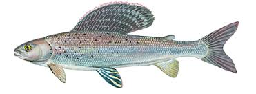

# What did we do last time?

- Implement data pipeline best practices
- Apply controlled vocabulary and naming conventions
- Create effective visualizations
- Customize plots for publication quality
- Combine multiple plots into composite figures

  ```r
  ggplot(name_df, aes(x_variable, y_variable, color = categorical_variable)) +
  #      dataframe, aesthetics(x and y variables, mapping of color or fill or shape) +
    geom_point() +
  # this it the geometry you want and can add more layers like
    geom_line()
  ```

- What questions do you have and what is unclear
- What did not work so far when you started the homework?

# Objectives and goals for today

## Today’s Objectives

1. Implement descriptive statistics in R
2. Calculate measures of central tendency and spread
3. Compare distributions of data from different groups
4. Create effective visualizations of descriptive statistics
5. Interpret the meaning of these statistics in a biological context

[figure not shown]

# Part 1: Setting Up Your Environment

First, let’s load the necessary packages and import our data:

```r
# Load required packages
library(tidyverse)    # For data wrangling and visualization
library(knitr)        # For creating tables
library(moments)      # For calculating skewness and kurtosis
library(flextable)
# Set a consistent theme for our plots
theme_set(theme_minimal(base_size = 12))
```

## Getting the data

**Practice Exercise 1: Loading and Examining the Grayling Data**

We’ll be working with data on arctic grayling fish from two different lakes (I3 and I8).

```r
# Write your code here to read in the file
# How do you examine the data - what are the ways you think and lets try it!

# Load the grayling data
grayling_df <- read_csv("data/gray_I3_I8.csv")
# View the first few rows
head(grayling_df)
```

```
# A tibble: 6 × 5
   site lake  species         length_mm mass_g
  <dbl> <chr> <chr>               <dbl>  <dbl>
1   113 I3    arctic grayling       266    135
2   113 I3    arctic grayling       290    185
3   113 I3    arctic grayling       262    145
4   113 I3    arctic grayling       275    160
5   113 I3    arctic grayling       240    105
6   113 I3    arctic grayling       265    145
```

```r
# Examine the data structure
glimpse(grayling_df)
```

```
Rows: 168
Columns: 5
$ site      <dbl> 113, 113, 113, 113, 113, 113, 113, 113, 113, 113, 113, 113, …
$ lake      <chr> "I3", "I3", "I3", "I3", "I3", "I3", "I3", "I3", "I3", "I3", …
$ species   <chr> "arctic grayling", "arctic grayling", "arctic grayling", "ar…
$ length_mm <dbl> 266, 290, 262, 275, 240, 265, 265, 253, 246, 203, 289, 239, …
$ mass_g    <dbl> 135, 185, 145, 160, 105, 145, 150, 130, 130, 71, 179, 108, 1…
```

```r
# Get a statistical summary
summary(grayling_df)
```

```
      site         lake             species            length_mm
 Min.   :113   Length:168         Length:168         Min.   :191.0
 1st Qu.:113   Class :character   Class :character   1st Qu.:270.8
 Median :118   Mode  :character   Mode  :character   Median :324.5
 Mean   :116                                         Mean   :324.5
 3rd Qu.:118                                         3rd Qu.:377.0
 Max.   :118                                         Max.   :440.0

     mass_g
 Min.   : 53.0
 1st Qu.:151.2
 Median :340.0
 Mean   :351.2
 3rd Qu.:519.5
 Max.   :889.0
 NA's   :2
```

```r
# How many fish do we have from each lake?
grayling_df %>%
  count(lake) %>% flextable()
```

| lake | n |
| --- | --- |
| I3 | 66 |
| I8 | 102 |

# Questions to Consider:

1. What variables are in our dataset?
2. What are their data types?
3. Are there any missing values?
4. What is the range of fish lengths in our dataset?
5. How many fish were sampled from each lake?

# Part 2: Calculating Descriptive Statistics

## Let’s calculate various descriptive statistics for our data:

**Practice Exercise 2: Measures of Central Tendency**

```r
# Write your code here to read in the file
# How do you examine the data - what are the ways you think and lets try it!
# Calculate the mean and median fish length
mean_length <- mean(grayling_df$length_mm)
median_length <- median(grayling_df$length_mm)

cat("Mean fish length:", round(mean_length, 1), "mm\n")
```

```
Mean fish length: 324.5 mm
```

```r
cat("Median fish length:", median_length, "mm\n")
```

```
Median fish length: 324.5 mm
```

```r
# Calculate mean and median by lake
grayling_df %>%
  group_by(lake) %>%
  summarise(
    mean_length = mean(length_mm),
    median_length = median(length_mm)
  ) %>%
  flextable()
```

| lake | mean_length | median_length |
| --- | --- | --- |
| I3 | 265.6061 | 266 |
| I8 | 362.5980 | 373 |

## Summarizing data - two ways

lets say we want to summarize the data and need to get n, means, standard deviation, standard error

We could do the following - if we had missing cells the code below would give an error

```r
mean(grayling_df$length_mm)
```

```
[1] 324.494
```

```r
mean(grayling_df$length_mm, na.rm = TRUE) # removes missing values
```

```
[1] 324.494
```

```r
length(grayling_df$length_mm)
```

```
[1] 168
```

## We need to learn to pipe things

- the dataframe –> pipe command that feed the dataframe into –> next command

```r
grayling_df %>% summarize(mean_length = mean(length_mm, na.rm = TRUE))
```

```
# A tibble: 1 × 1
  mean_length
        <dbl>
1        324.
```

## What is cool is we can do a lot of different things now

```r
grayling_df %>%
  summarize(
    mean_length = mean(length_mm, na.rm = TRUE),
    sd_length = sd(length_mm, na.rm = TRUE),
    n_length = n())
```

```
# A tibble: 1 × 3
  mean_length sd_length n_length
        <dbl>     <dbl>    <int>
1        324.      65.0      168
```

## Super cool code in case there are missing values

```r
grayling_df %>%
  summarize(
    mean_length = mean(length_mm, na.rm = TRUE),
    sd_length = sd(length_mm, na.rm = TRUE),
    n_length = sum(!is.na(length_mm)))
```

```
# A tibble: 1 × 3
  mean_length sd_length n_length
        <dbl>     <dbl>    <int>
1        324.      65.0      168
```

# Now for Spread…

**Practice Exercise 3: Measures of Spread**

```r
# Write your code here to read in the file
# Calculate standard deviation, variance, and IQR
sd_length <- sd(grayling_df$length_mm)
var_length <- var(grayling_df$length_mm)
iqr_length <- IQR(grayling_df$length_mm)

cat("Standard deviation:", round(sd_length, 1), "mm\n")
```

```
Standard deviation: 65 mm
```

```r
cat("Variance:", round(var_length, 1), "mm²\n")
```

```
Variance: 4225.9 mm²
```

```r
cat("Interquartile range:", iqr_length, "mm\n")
```

```
Interquartile range: 106.25 mm
```

**Exercise 4: Calculate Quartiles and Percentiles**

```r
# Calculate quartiles for overall data
quartiles <- quantile(grayling_df$length_mm, probs = c(0.25, 0.5, 0.75))
# cat("First quartile (Q1):", quartiles[1], "mm\n")
# cat("Second quartile (Median):", quartiles[2], "mm\n")
# cat("Third quartile (Q3):", quartiles[3], "mm\n")

# Calculate a more comprehensive set of percentiles
percentiles <- quantile(grayling_df$length_mm,
                        probs = c(0.1, 0.25, 0.5, 0.75, 0.9))

# Display the percentiles using flextable
data.frame(
  Percentile = c("10th", "25th (Q1)", "50th (Median)", "75th (Q3)", "90th"),
  Value = percentiles
) %>%
  flextable() %>%
  set_caption("Key Percentiles of Fish Length (mm)") %>%
  colformat_double(j = "Value", digits = 1) %>%
  autofit()
```

| Percentile | Value |
| --- | --- |
| 10th | 251.1 |
| 25th (Q1) | 270.8 |
| 50th (Median) | 324.5 |
| 75th (Q3) | 377.0 |
| 90th | 408.6 |

### Note you could add a box plot by lake to see this if you wanted

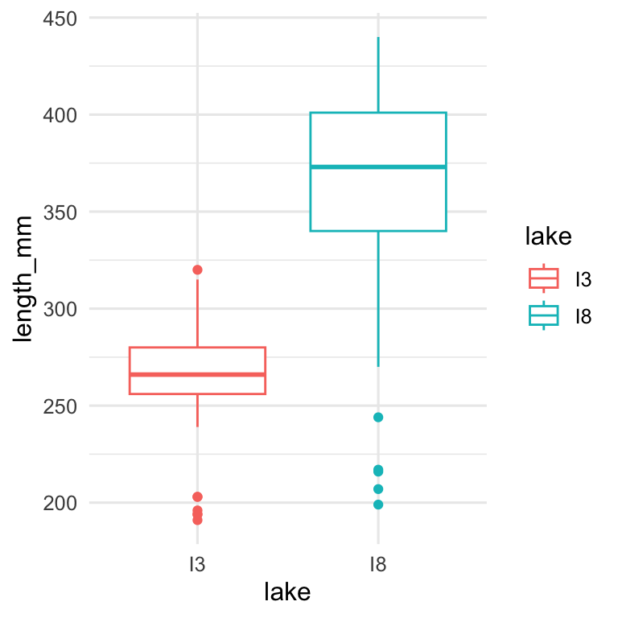

```r
grayling_df %>%
  ggplot(aes(lake, length_mm, color= lake))+
  geom_boxplot()
```

**Exercise 5: Calculate the Coefficient of Variation**

The coefficient of variation (CV) is the standard deviation expressed as a percentage of the mean:

$$CV = \frac{s}{\bar{Y}} \times 100\%$$

```r
# Calculate coefficient of variation
cv_length <- sd_length / mean_length * 100
cat("Coefficient of variation:", round(cv_length, 1), "%\n")
```

```
Coefficient of variation: 20 %
```

```r
# Calculate by lake
grayling_df %>%
  group_by(lake) %>%
  summarise(
    mean_length = mean(length_mm),
    sd_length = sd(length_mm),
    cv_length = sd_length / mean_length * 100
  ) %>%
  flextable()
```

| lake | mean_length | sd_length | cv_length |
| --- | --- | --- | --- |
| I3 | 265.6061 | 28.30378 | 10.65630 |
| I8 | 362.5980 | 52.33901 | 14.43444 |

### Questions to Consider:

1. How do the means and medians compare within each lake? What might this tell you about the distribution?
2. Which lake has more variable fish lengths? How can you tell?
3. Why might the coefficient of variation be useful when comparing variability between different measurements (e.g., length vs. mass)?

## Part 3: Visualizing Distributions

Visualizations can help us better understand the descriptive statistics we’ve calculated.

**Exercise 6: Creating Histograms**

One of the best ways to look at data is a histogram - and we will do it again

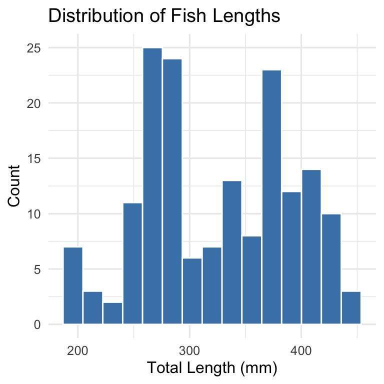

```r
# Create a histogram of all fish lengths
ggplot(grayling_df, aes(x = length_mm)) +
  geom_histogram(bins = 15, fill = "steelblue", color = "white") +
  labs(
    title = "Distribution of Fish Lengths",
    x = "Total Length (mm)",
    y = "Count"
  )
```

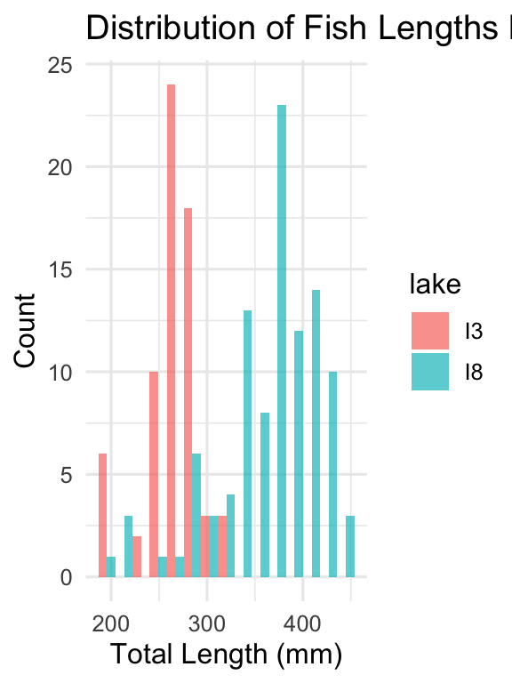

```r
# Create histograms by lake
ggplot(grayling_df, aes(x = length_mm, fill = lake)) +
  geom_histogram(bins = 15, position = "dodge", alpha = 0.7) +
  labs(
    title = "Distribution of Fish Lengths by Lake",
    x = "Total Length (mm)",
    y = "Count"
  )
```

**Exercise 7: Creating Box Plots**

Personally I like box plots

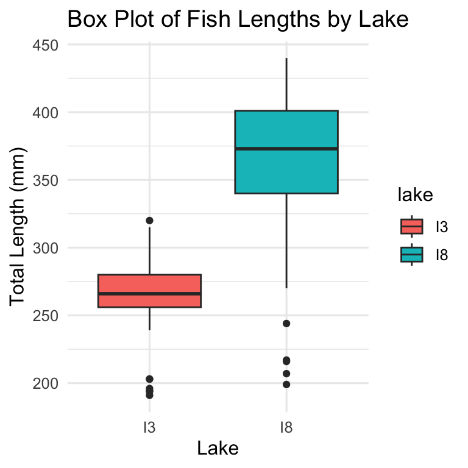

```r
# Create a box plot comparing fish lengths by lake
# Create a box plot comparing fish lengths by lake
ggplot(grayling_df, aes(x = lake, y = length_mm, fill = lake)) +
  geom_boxplot() +
  labs(
    title = "Box Plot of Fish Lengths by Lake",
    x = "Lake",
    y = "Total Length (mm)"
  )
```

**Exercise 9: Creating Density Plots**

Now these will be really important later on

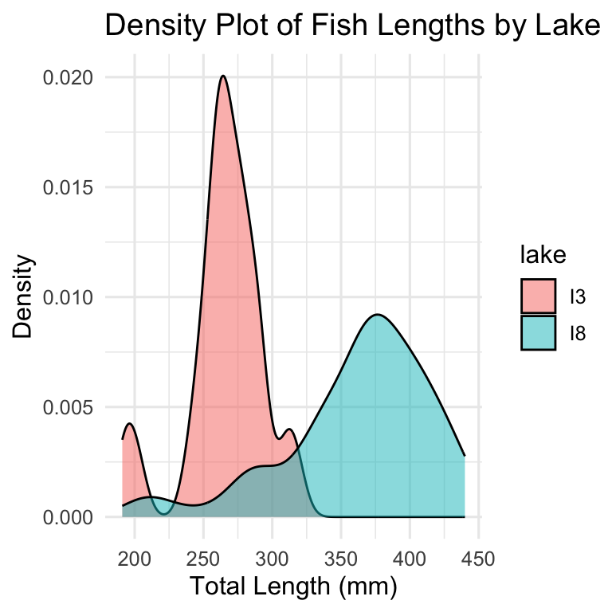

```r
## Create density plots
ggplot(grayling_df, aes(x = length_mm, fill = lake)) +
  geom_density(alpha = 0.5) +
  labs(
    title = "Density Plot of Fish Lengths by Lake",
    x = "Total Length (mm)",
    y = "Density"
  )
```

## Guided Questions for Deeper Understanding of descriptive statistics

1. **Biological Interpretation**: What ecological factors might explain the differences in fish size between the two lakes?
2. **Statistical Reasoning**: Why might we prefer to use the median and IQR instead of the mean and standard deviation in some cases?
3. **Data Visualization**: Which visualization method was most effective for comparing the two lakes? Why?
4. **Scientific Communication**: How would you concisely summarize these findings in a scientific paper?
5. **Further Analysis**: What additional analyses might be useful to better understand this dataset?

Back to top